# Introduction to Git

**What is Git, what is the difference between GitHub and GitLab?**

Imagine working on a same code base or project with some developers. How we can do this without any conflicting. Well, we can do this with Git, GitHub, or GitLab command.

**Git** is *distributed version control system* (VCS). It is a system that tracks changes to project files over time and enables to record project changes and go back to a specific version of the tracked files, at any given point in time.

**GitHub/GitLab** are hosted Git. Where Git is the underlying system that runs on your machine, GitHub/GitLab is hosted on the cloud or via the web. These allows developers from all over the world can work together and collaborate on different codes or projects.

Some benefits of Git/GitHub:

- Track the changes, It states the changes at anytime
- Historical Backup-"Snapshop" it is like `save as` bottom. We can keep a previous version and revert to if we need to, while sill copying and then making changing on top of that previous version
- Team based development
- Flexible. It allows to work locally on a project, or Git/GitHub can be used as your DevOps flows so we can integrate our repository, so kick off automated testing.
- Git is typically interacted with command line on local machine while Git is on the web.
- Trunk-based development. See Figure below. Each developer can branch off of the main branch of code, make some changes and merge the code back into the main branch.

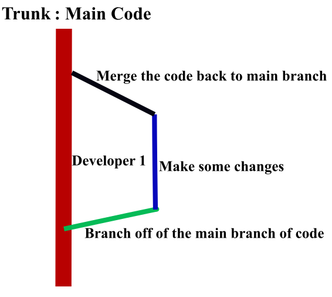

If we had a repository which is a place to store your code and changes to your code. It can be hosted on cloud or web (GitHub). If I want to work on that code on my local machine, I should clone this repo onto my local machine and create my trunk-based development. Then I should create a branch of code called for example `Mehdi-Branch`. Next is to create our application, called it `working-copy`, commit it and finally push it back to repo. Coworker should go through this process and have pull request to ask for review the code.

[figure not shown]

So, Git is a tool that manages changes made to the files and directories in a project.

- Material saved to Git can never be lost.
- When your work has conflicts with someone else's, Git automatically notifies you. Therefore, so it's harder to accidentally overwrite work.

## Set up

Git can be downloaded from here: https://git-scm.com/downloads. Download Git and follow the instruction to get things set up on your computer.

After installing, type `git --version` on your terminal to verify that Git is ready to use:

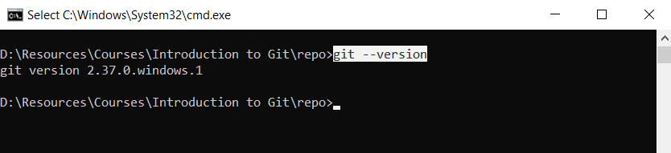

## Setting Name & Email

Run the following commands in your terminal, to identify yourself with Git. Notice, this name and email has no application other than reporting:

`git config --global user.name "Name"`

`git config --global user.email "Example@email.com"`

## Repositories

**Where information is stored by Git?**

Each Git project has two part:

- files and directories that you created and edit directly
- Extra information that Git stores about project's history

The combination of two parts is called **repository**

A repository can be initialized by `git init` that initializes a repository

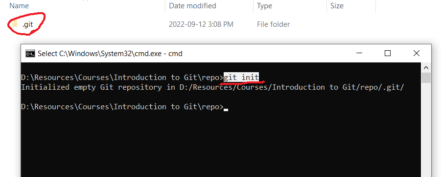

Extra information will be stored directly in directory called `.git` located in root directory of the repository. `.git` should not be edited or deleted.

Two major types of Git repositories are:

- **Local repository** - you can work on the local version of your project on an isolated repository stored on your own computer.
- **Remote repository** - stored outside of isolated local system, usually on a remote server, web or cloud such as GitHub, GitLab. This is the place to share project code, see other people's code and integrate it into local version of the project, and also push the changes to the remote repository.

## Check the status

**How to track what have been changed?**

There is a **staging area** to store files with changes you want to save that haven't been saved yet. Files in the staging area is similar to having them in box, while committing means mailing those files: data in box can be changed, added , but after committing (mailing), further changes cannot be done.

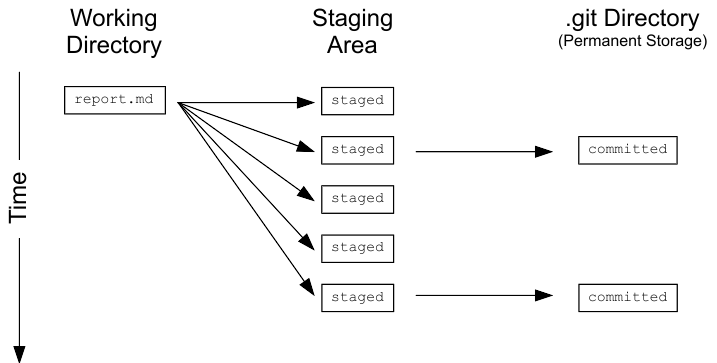

`git status` shows the files are in **staging area**, and the files have changes that haven't yet been put there.

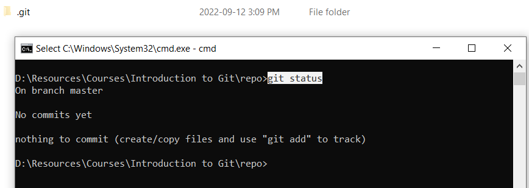

since we do not change the repo, there is no commit

## Staging files

`mkdir diff-demo`

`cd diff-demo`

`git init`

`echo hello > myfile.txt`

`git add myfile.txt`

We can append new line to the end of the file:

`echo “text_2” >> myfile.txt`

To add multiple files, we can do this:

`git add myfile1.txt myfile2.txt myfile3.txt`

This can be tedious, instead of adding the files individually, all the files inside the project folder can be added to the staging area by the command below:

`git add .`

## Making commits

A **commit** is considered as a snapshot of our code at a particular time, which we are saving to the commit history of our repository. `git commit` is used to save the changes in the staging area. It always saves everything that is in the staging area as one unit. Git requires you to enter a **log message** while committing changes. It keeps informed the next person to examine the repository why you made a change. By default, Git launches a text editor for writing this message. You can use -m "some message in quotes" on the command line as:

`git commit -m "Add text file"`

if a message is accidentally mistyped, it can be changed by `--amend` flag.

`git commit --amend - m "edited message"`

## View Commit History

The command `git log` is used to view the log of the project's history. Log entries are shown most recent first, and look like this:

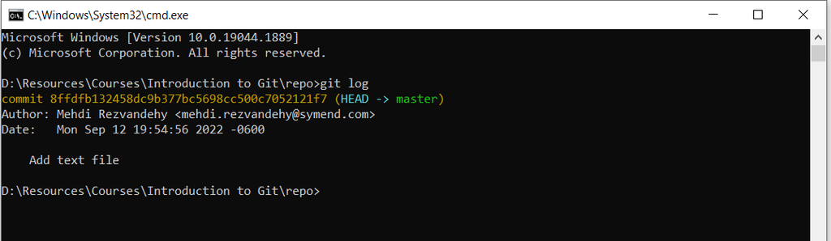

The `commit` line displays a unique ID for the commit called a **hash**. The other lines tell who made the change, when, and what log message they wrote for the change.

It's often useful to inspect only the changes to particular files or directories since a project's entire log can be overwhelming. It can be done using `git log path`, where `path` is the path to a specific file or directory.

The following command can be used to go back to a previous state of committed project code:

`git checkout <commit-hash>`

Replace `<commit-hash>` with the actual hash to visit, listed with the git log command.

## What is in a diff?

A `diff` is a formatted display of the differences between two sets of files. `git diff` shows all the changes in your repository, while `git diff directory` shows the changes to the files in some directory.

The first comparison is already created. Just run `git diff` and the results will be:

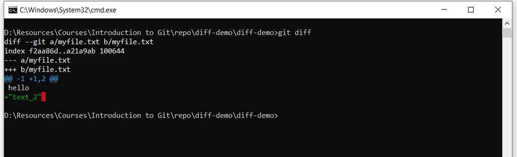

- a and b are placeholders meaning "the first version" and "the second version".
- An index line is keys into Git's internal database of changes.
- --- a/myfile.txt and +++ b/myfile.txt, wherein lines being removed are prefixed with - and lines being added are prefixed with +.
- A line starting with @@ that tells where the changes are being made.
- -showing deletions and + showing additions

A file can be added to **staging area** by `git add filename` (`git add myfile.txt`)

# Repositories

**How Information are Stored by Git**

Git uses a three-level structure to store information by each commit.

**What is a hash?**

Hashes make Git capable of sharing data between repositories. Hashes guaranteed for the same files should be the same. If two commits contain the same files and have the same ancestors, their hashes will be the same as well.

lines that the change removed are prefixed with -, while lines that it added are prefixed with +.

# Branches

**branch** could be considered as an individual timeline of project commits.

Git allows to create many of alternative environments (**branches**) so other versions of our project code can exist and be tracked in parallel.

That allows us to add new features in separate branches, without touching the '*official'* or **master** branch of the project. When a repository is initialized and commits are started, they are automatically saved to the **master** branch by default.

## Creating a new branch

The following command can be used to create a new branch:

`git branch <new-branch-name>`

## Changing branches

`git checkout` command can be used to switch to a different branch.

To go back to **master** branch, we can use this command:

`git checkout master`

## See all Branches my Repository

Every Git repository by default has a branch called `master`. You can run the command `git branch` to list all of the branches in a repository. The branch you are currently in will be shown with a `*` beside its name.

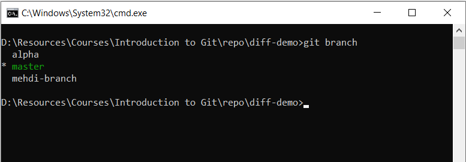

## View Difference between Branches

Branches and revisions are closely connected, and commands that work on the latter usually work on the former. For example, just as git `diff revision-1..revision-2` shows the difference between two versions of a repository, `git diff branch-1..branch-2` shows the difference between two branches.

# Create a Local Repository and Push it into GitHub

1. First Create a local project.
1. convert working directory into GitHub repository by `git init` (it creates .git folder in the folder confirming git repository).

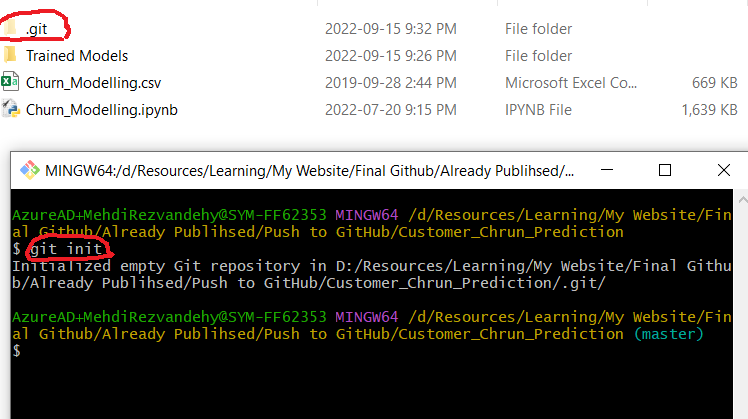

1. Use `git add .` command to add all files to the staging area.
1. Add first commit by `git commit -m "First Commit"`.
1. Then go to GitHub and create a repository as below:

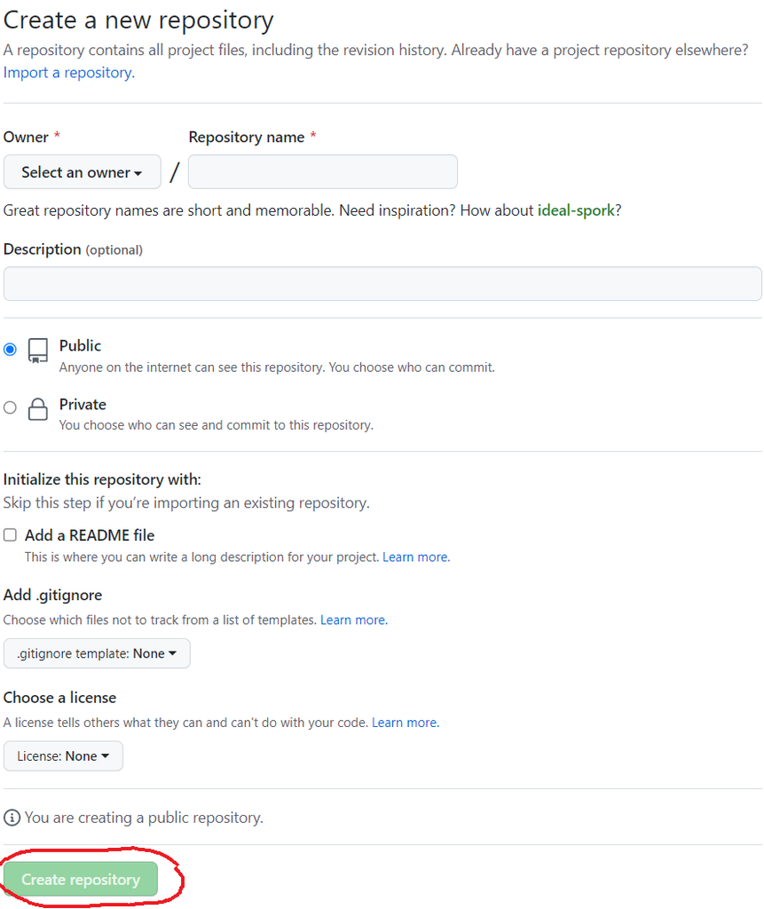

1. Copy the link of GitHub repository.
1. Go back to terminal and write this command `git remote add origin` +paste the url of repository.
1. Next use `git push -u origin master` to push local library to GitHub
1. Finally use `git push --set-upstream origin master` command: local master branch is linked to remote master branch now
1. Any change to local repository can be easily pushed to GitHub by:
   1. `git add .`: add files to the staging area.
   2. `git commit -m "add a message"`: make a commit
   3. `git push`: push local branch to GitHub

# Reference

1. https://www.youtube.com/watch?v=wpISo9TNjfU&ab_channel=IBMTechnology
1. https://www.youtube.com/watch?v=USjZcfj8yxE&ab_channel=ColtSteele
1. https://www.notion.so/zarkom/Introduction-to-Git-ac396a0697704709a12b6a0e545db049